# Part II - To Prosper with Loans

## by Dolu Solana

## Investigation Overview

We examined data after the 2009 when the prosper scores were created. To discover:

## Dataset Overview

In this project we would conduct analysis loan data gotten from Prosper Loans, a San Francisco based peer-to-peer loaning app. The data consists of information such as borrower's rate, occupation, creditScore and other information.

## How Loan Terms Are Distributed Across the Data

Loan's are given out in three time frames. 12 Months, 36 Months and 60 Months. The most popular term is 36 months by a considerable margin

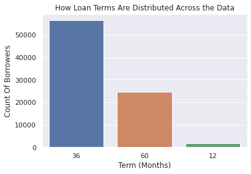

## The Relationship Between Prosper Scores and Credit Scores

While Prosper Scores seem to have a relationship with traditional credit scores, it seems to be non-linear i.e A higher credit score doesn't always correspond with a high prosper score. A more indepth analysis will be needed to conclude on what factors directly impact prosper scores.

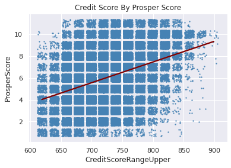

[figure not shown]

## The relationship between Prosper Scores and Loan Amounts.

Prosper scores also tend to have a relationship with loan amount i.e Low prosper scores have rarely have high loan amounts. Though this relationship is not linear.

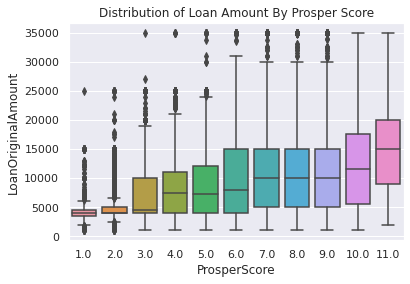

## The relationship between Loans Amounts and Prosper Scores after considering Loan Term

We also observe that high loan amounts are really given out in for short loan terms, we observed that 12-month loan terms maxed out around 25000.

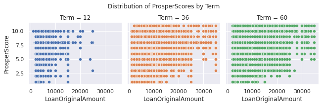

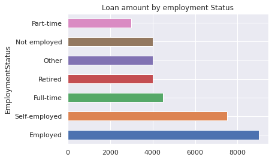